# About

Heng Tse Chou

3 June 2022

## Introduction

This is my semester final project for Statistical Computing 2022 in NTHU Dept. of Statistics. The shiny app ‘GMM clustering’ is a visualization of soft labeling classification via Gaussian mixture models, which is an application of expectation maximization (EM) algorithm.

It shows visuals of corresponding contour plots or pdf curve, along with data points. For one dimensional data, data points are shown by a histogram; for data more than one dimension, it will be shown by a paired scatter plot.

## How to use

This app is very simple and straight forward.

1. Go to Table import. Upload a csv file of your own, or choose an example dataset.
2. Go to Plot. There, you can input k and see how they cluster.
3. Also, it is capable of showing AIC and BIC score in user-given range.

## Showcase

User are allowed to import csv file or choose from example datasets. Then, the shiny app can return estimates of weights, mu and sigma for the k-th Gaussian distribution component, k can be set by user arbitrarily (Very high k may gives weird result or being not able to cluster).

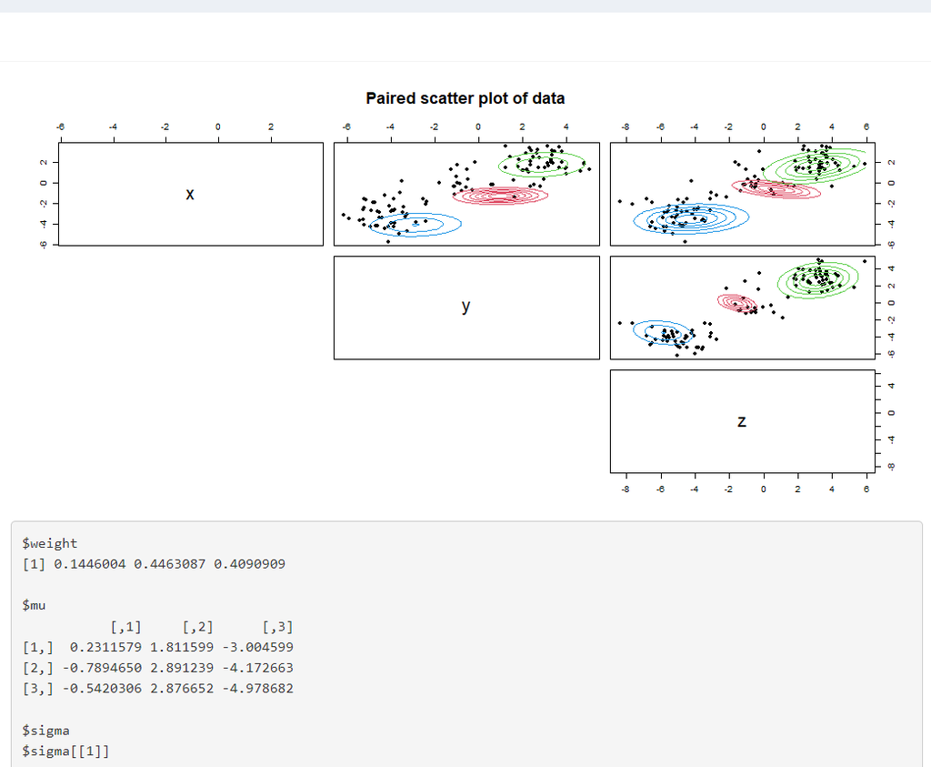

This app also provides BIC and AIC score for the given dataset. The definition of two criteria is as below:

$$\begin{aligned}
&BIC = -2\log(\hat{L})+k \log(n)\\
&AIC = -2\log(\hat{L})+2k
\end{aligned}$$

We use a mean score in 5 times of computation for each k. Usually, we consider the k with lower score or being an elbow point a good choice. However, one should note that their ability of finding optimal k for the underlying true model is still case by case.

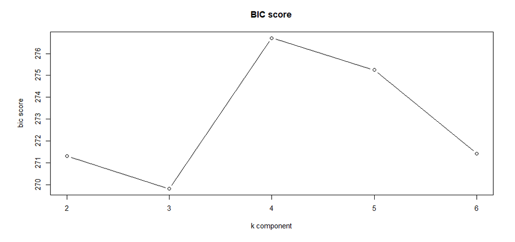

*Note: this is a considerably simple realization of my coursework, so it may not be very adaptable to all kinds of data, for example, datetime data. Moreover, only numerical is accepted.*

My Github: (https://github.com/hank-chouu)

## Dependency

The project was built under R version 4.0.4, along with the following additional packages:

- `shinydashboard_0.7.2`
- `shiny_1.6.0`
- `mclust_5.4.9` (only `dmvnorm` is used)
- `MASS_7.3-53`

## Inplementation

This section shows the basic idea of this project.

### 1. E-step

```r
e_step <- function(X, para, k){

  n <- dim(X)[1]
  z <-  matrix(NA, nrow=n, ncol= k)
  sum_of_comps <- rep(0, n)

  for (i in 1:k){
    dmv <- dmvnorm(X, para$mu[, i], para$sigma[[i]])
    comp <- dmv * para$weight[i]
    sum_of_comps <- sum_of_comps + comp
  }

  for (i in 1:k){
    dmv <- dmvnorm(X, para$mu[, i], para$sigma[[i]])
    comp_post <- dmv * para$weight[i] / sum_of_comps
    z[, i] <- comp_post
  }

  sum_of_comps_ln <- log(sum_of_comps)
  sum_of_comps_ln_sum <- sum(sum_of_comps_ln)

  list(z=z, lld=sum_of_comps_ln_sum)
}
```

### 2. M-step

```r
m_step <- function(X, z, k){

  n <- dim(X)[1]
  d <- dim(X)[2]
  w.next <- rep(0, k)
  mu.next <- matrix(0, d, k)
  sigma.next <- list()

  for (i in 1:k){

    new.w <- sum(z[, i])/n
    w.next[i] <- new.w

    new.mu <- 1/sum(z[, i])*colSums(z[, i]* X)
    mu.next[, i] <- new.mu

    new.mu <- matrix(rep(new.mu, n), n, d, byrow = T)

    new.sigma <- 1/sum(z[, i]) * t(z[, i]*(X - new.mu)) %*% (z[, i]*(X - new.mu))
    sigma.next[[i]] <- new.sigma
  }

  para.next <- list(weight = w.next, mu = mu.next, sigma = sigma.next)
  return(para.next)
}
```

### 3. Initialization

GMM Clustering provides two methods for initializing parameters: `kmeans` and `runif`. With `kmeans` being more stable, it is set as default method. However, very rarely it may results in error of sigma being a symmetric matrix in the succeeding steps. After a few tries, the app will turn for `runif` for initialization, which is more flexible but often does not give the best initial points as we expected.

```r
para_initialize <- function(X, k, method){ # X should be a matrix

  d <- dim(X)[2]
  w <- rep(1/k, k)

  init_mu <- matrix(0, d, k)

  if (method == 'runif'){

    for (i in 1:k){
      for (j in 1:d){
        init_mu[j, i] = runif(1, min(X[, j]), max(X[, j]))
      }
    }
  }

  if (method == 'kmeans'){
    init_mu <- t(kmeans(X, centers = k)$centers)
  }

  init_sigma <- list()
  for (i in 1:k){
    init_sigma[[i]] <- diag(d)
  }
  para <- list(weight = w, mu = init_mu, sigma = init_sigma)
  return(para)
}
```

### 4. The gmm_em function

```r
generalize_gmm <- function(x, k, init.method){

  X <- as.matrix(x)
  para <- para_initialize(X, k, init.method)

  e.step <- e_step(X, para, k) # return z, lld
  para <- m_step(X, e.step$z, k) # return new para
  cur.loglik <- e.step$lld
  loglik.vector <- e.step$lld
  loglik.diff <- 1
  count <- 1

  while(loglik.diff > 1e-6){

    e.step <- e_step(X, para, k)
    para <- m_step(X, e.step$z, k)

    count <- count + 1
    # print(count)
    if (count > 300){
      stop('reached max iters')
    }
    loglik.vector <- c(loglik.vector, cur.loglik)
    loglik.diff <- abs((cur.loglik - e.step$lld))
    cur.loglik <- e.step$lld

  }
  cluster <- factor(apply(e.step$z, 1, which.max))
  list(para=para, z=e.step$z, count=count, lld_vector=loglik.vector, lld=cur.loglik, cluster=cluster)
}
```

When `kmeans` or `runif` are not working and giving bad results, such as making sigma a symmetric matrix, iterating for longer than we expected, etc. A re-boost with new initial points will generally fix the problem. Here, I wrapped the retry procedure for simplicity:

```r
wrapped_gmm <- function(X, k){

  count <- 0
  max_count <- 10

  while (count <= max_count) {
    res <- try({
      result <- generalize_gmm(X, k, 'kmeans')
      result
    }, silent = TRUE)
    count <- count + 1
    if (!inherits(res, "try-error")) {
      return(res)
      break
    }
  }
  count <- 0
  while (count <= 300) {
    res <- try({
      result <- generalize_gmm(X, k, 'runif')
      result
    }, silent = TRUE)
    count <- count + 1
    if (!inherits(res, "try-error")) {
      return(res)
      break
    }
  }
  stop('unable to cluster')
}
```

## References

Shiny and mathematical materials are mostly from:

- [Visualisation of soil profiles by Gabrielname](https://shiny.rstudio.com/gallery/soil-profiles.html)
- 機器學習: EM 演算法(Expectation-Maximization Algorithm, EM)、高斯混合模型(Gaussian Mixture Model, GMM)和GMM-EM詳細推導
- [Latent variable models, part 1](https://krasserm.github.io/2019/11/21/latent-variable-models-part-1/)
- [An Intro to Gaussian Mixture Modeling](https://www.r-bloggers.com/2017/02/an-intro-to-gaussian-mixture-modeling/)
- [Introduction to EM: Gaussian Mixture Models](https://stephens999.github.io/fiveMinuteStats/intro_to_em.html)

and many helps from StackOverflow.